# R Notebook, TMV vs HTT

# Steg 1: Lägg in data

Spara uppmätt data i variabler:

```r
tmv4_v <- c(-1, -3, -5, 3, -9, 5, -1, -1, 10, -1, 4, 3, -1, 0)
tmv3_v <- c(-2, -5, -5, 0, -10, 3, -1, 0, 13, 1, 0, 2, 0, 2)
htt_v  <- c(3, 5, 4, 7, -2, 8, -6, 8, 8, 4, 12, 3, 5, 8)
tmv4_h <- c(1, -5, 3, 3, -4, 8, 0, -1, 11, 0, 4, 3, -3, 5)
tmv3_h <- c(2, -6, 0, 2, -3, 7, 0, -1, 12, 3, 2, 3, -2, 3)
htt_h  <- c(4, 5, 4, 3, 5, 8, -6, 8, 13, 4, 8, 7, 9, 8)
```

Formattera datan i en *data frame*:

```r
d <- data.frame(
  sida <- c(rep("Vänster", 14), rep("Höger", 14)),
  HTT <- c(htt_v, htt_h),
  TMV3 <- c(tmv3_v, tmv3_h),
  TMV4 <- c(tmv4_v, tmv4_h)
)
```

Denna data frame innehåller fyra olika listor:

- `sida` bestämmer vilken av grupperna “Vänster” och “Höger” som en viss punkt tillhör. Den består av strängen `"Vänster"` upprepad 14 gånger, följt av `"Höger"` upprepad 14 gånger.
- `HTT` består av alla HTT-värden från vänster sida (14 st), följt av alla HTT-värden från höger sida (14 st).
- `TMV3` och `TMV4` följer motsvarande mönster som `HTT`.

Note: vi kan komma åt datan inuti en data frame med dollartecken-operatorn: för att t.ex. komma åt enbart listan `HTT` så skriver vi

```r
d$HTT
```

```
 [1]  3  5  4  7 -2  8 -6  8  8  4 12  3  5  8  4  5  4  3  5  8 -6  8 13  4  8  7  9  8
```

Vi kan även testa

```r
d$sida
```

```
 [1] Vänster Vänster Vänster Vänster Vänster Vänster Vänster Vänster Vänster Vänster Vänster Vänster Vänster Vänster
[15] Höger   Höger   Höger   Höger   Höger   Höger   Höger   Höger   Höger   Höger   Höger   Höger   Höger   Höger
Levels: Höger Vänster
```

Här ser vi listan som består av just 14 st `"Vänster"` och 14 st `"Höger"`, men utöver detta så ser vi också texten “Levels: Höger Vänster”; här berättar R för oss att datan i `d` tillhör en av två “nivåer”, kallade “Vänster” och “Höger”.

# Steg 2: Linjär regression

För att anpassa en linjär modell använder vi funktionen `lm()`. Om vi vill se hur bra `tmv3_v` passar som en linjär funktion av `htt_v` så skapar vi en linjär modell genom `lm(tmv3_v ~ htt_v)`. Vi kan sen printa ut en sammanfattning av den linjära anpassningen via `summary()`:

```r
summary(lm(tmv3_v ~ htt_v))
```

```
Call:
lm(formula = tmv3_v ~ htt_v)

Residuals:
    Min      1Q  Median      3Q     Max
-6.3532 -3.0660 -0.4514  1.5322 11.4831

Coefficients:
            Estimate Std. Error t value Pr(>|t|)
(Intercept)  -2.6141     1.8787  -1.391   0.1894
htt_v         0.5164     0.2896   1.783   0.0999 .
---
Signif. codes:  0 ‘***’ 0.001 ‘**’ 0.01 ‘*’ 0.05 ‘.’ 0.1 ‘ ’ 1

Residual standard error: 4.745 on 12 degrees of freedom
Multiple R-squared:  0.2094,    Adjusted R-squared:  0.1435
F-statistic: 3.178 on 1 and 12 DF,  p-value: 0.09992
```

Vi ser ett R2-värde på 0.2094 och ett p-värde på 0.09992. För resterande data har vi:

**TMV3 mot HTT, höger**:

```r
summary(lm(tmv3_h ~ htt_h))
```

```
Call:
lm(formula = tmv3_h ~ htt_h)

Residuals:
    Min      1Q  Median      3Q     Max
-7.2681 -2.8674  0.6702  2.0128  7.3345

Coefficients:
            Estimate Std. Error t value Pr(>|t|)
(Intercept)  -0.8553     1.8759  -0.456    0.657
htt_h         0.4247     0.2657   1.599    0.136

Residual standard error: 4.123 on 12 degrees of freedom
Multiple R-squared:  0.1756,    Adjusted R-squared:  0.1069
F-statistic: 2.555 on 1 and 12 DF,  p-value: 0.1359
```

**TMV4 mot HTT, vänster**:

```r
summary(lm(tmv4_v ~ htt_v))
```

```
Call:
lm(formula = tmv4_v ~ htt_v)

Residuals:
    Min      1Q  Median      3Q     Max
-5.3545 -2.7926 -0.5426  2.5996  7.9574

Coefficients:
            Estimate Std. Error t value Pr(>|t|)
(Intercept)  -2.5079     1.5819  -1.585   0.1389
htt_v         0.5688     0.2439   2.332   0.0379 *
---
Signif. codes:  0 ‘***’ 0.001 ‘**’ 0.01 ‘*’ 0.05 ‘.’ 0.1 ‘ ’ 1

Residual standard error: 3.995 on 12 degrees of freedom
Multiple R-squared:  0.3119,    Adjusted R-squared:  0.2546
F-statistic:  5.44 on 1 and 12 DF,  p-value: 0.03791
```

**TMV4 mot HTT, höger**:

```r
summary(lm(tmv4_h ~ htt_h))
```

```
Call:
lm(formula = tmv4_h ~ htt_h)

Residuals:
   Min     1Q Median     3Q    Max
-6.483 -3.081  0.957  2.335  6.125

Coefficients:
            Estimate Std. Error t value Pr(>|t|)
(Intercept)  -0.6376     1.9349  -0.330    0.747
htt_h         0.4241     0.2740   1.548    0.148

Residual standard error: 4.253 on 12 degrees of freedom
Multiple R-squared:  0.1664,    Adjusted R-squared:  0.09691
F-statistic: 2.395 on 1 and 12 DF,  p-value: 0.1477
```

# Steg 3: Figurer med ggplot

Vi skapar punktdiagram med R-paketet `ggplot2`, som vi först måste importera:

```r
library(ggplot2)
```

Sedan skapar vi våra figurer:

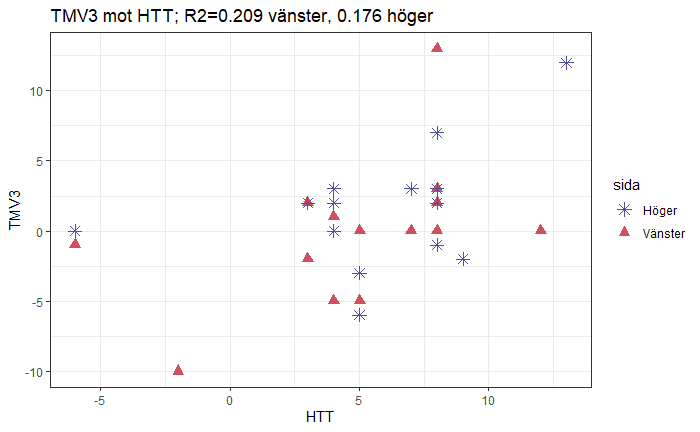

```r
ggplot(d, aes(x=HTT, y=TMV3)) +
  geom_point(aes(colour=sida, shape=sida), size=3) +
  ggtitle("TMV3 mot HTT; R2=0.209 vänster, 0.176 höger") +
  theme_bw() +
  scale_shape_manual(values=c(8, 17)) +
  scale_colour_manual(values=c("#5050a0", "#d05060"))
```

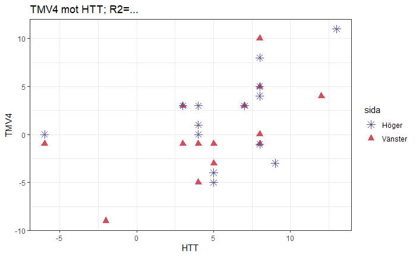

```r
ggplot(d, aes(x=HTT, y=TMV4)) +
  geom_point(aes(colour=sida, shape=sida), size=3) +
  ggtitle("TMV4 mot HTT; R2=...") +
  theme_bw() +
  scale_shape_manual(values=c(8, 17)) +
  scale_colour_manual(values=c("#5050a0", "#d05060"))
```

# Om man vill skriva mer cool kod

Att manuellt behöva köra några rader kod, sen pausa och läsa R2-värdet, för att sedan manuellt skriva in R2-värdet i sin figurtitel är lite jobbigt (speciellt om man ska skapa många grafer). Men programmering är till för att automatisera saker. Vi kan t.ex. spara vår summary av den linjära anpassningen

```r
summary_tmv3_v <- summary(lm(tmv3_v ~ htt_v))
summary_tmv3_h <- summary(lm(tmv3_h ~ htt_h))
```

och sedan komma åt R2-värdet som en variabel, med dollartecken-operatorn, via

```r
summary_tmv3_v$r.squared
```

```
[1] 0.2093973
```

Det ser ju rätt ut, så där har vi R2-värdet direkt i vår kod. Så vi sparar det i en variabel!

```r
R2_tmv3_v <- summary_tmv3_v$r.squared
R2_tmv3_h <- summary_tmv3_h$r.squared
```

Nu kan vi använda funktionen `sprintf()` (som finns i många programmeringsspråk, inte bara i R) för att skapa vår titeltext. Det vi vill göra ser ut såhär:

```r
sprintf("TMV3 mot HTT; R2=%.3f vänster, R2=%.3f höger", R2_tmv3_v, R2_tmv3_h)
```

```
[1] "TMV3 mot HTT; R2=0.209 vänster, R2=0.176 höger"
```

`sprintf` står typ för “string print formatted” eller något; den *formatterar* en textsträng, sen *printar* den in resultatet i en *sträng*. Det är en standardfunktion i de flesta språk. Det först argumentet är en *formatsträng*, som innehåller text och specialtecknet `%` som bestämmer en formattering av ett tal. Varje procenttecken i strängen matchas sen med de argument som sprintf får efteråt; det första procenttecknet matchas mot `R2_tmv3_v`, det andra mot `R2_tmv3_h`. De är lite skumma i början, men man lär sig efter man googlat 1000 gånger. Formatet `%.3f` innehåller två bitar information: `f` står för “floating point number”, som är datorspråk för *decimaltal* (till skillnad från heltal). Detta betyder att variabeln `R2_tmv3_v` ska tolkas som ett decimaltal. Nästa del av formatet är `.3` som betyder att vi vill ha tre siffror efter decimaltecknet.

För att ge mer exempel: heltal formatteras som `%d` (d som i digit), t.ex:

```r
sprintf("lite text, %d, lite mer text", 18)
```

```
[1] "lite text, 18, lite mer text"
```

```r
sprintf("En följd av heltal: %d, %d, %d och %d.", 1, -2, 3, 0)
```

```
[1] "En följd av heltal: 1, -2, 3 och 0."
```

```r
sprintf("Ett heltal: %d. Ett decimaltal med hur många siffror det vill: %f. Samma tal med 2 decimaler: %.2f", 255, R2_tmv3_h, R2_tmv3_h)
```

```
[1] "Ett heltal: 255. Ett decimaltal med hur många siffror det vill: 0.175558. Samma tal med 2 decimaler: 0.18"
```

Coolt. Men tillbaka till vår titel. Jag tänker välja att spara den i en variabel:

```r
titel_tmv3 <- sprintf("TMV3 mot HTT; R2=%.3f vänster, R2=%.3f höger", R2_tmv3_v, R2_tmv3_h)
```

Sen kan man bara använda den när vi använder `ggplot()`! Så istället för att ha `+ ggtitle("TMV3 mot HTT; R2=0.209 vänster, 0.176 höger")` så räcker det med `+ ggtitle(titel_tmv3)`. Om vi slår ihop allt det här så får vi detta skript:

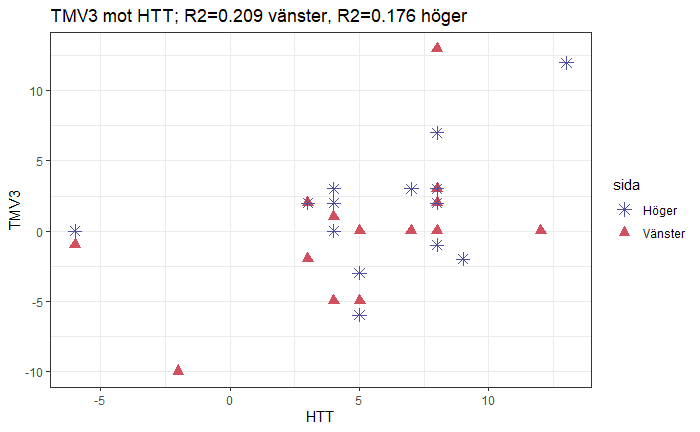

```r
summary_tmv3_v <- summary(lm(tmv3_v ~ htt_v))
summary_tmv3_h <- summary(lm(tmv3_h ~ htt_h))

R2_tmv3_v <- summary_tmv3_v$r.squared
R2_tmv3_h <- summary_tmv3_h$r.squared

titel_tmv3 <- sprintf("TMV3 mot HTT; R2=%.3f vänster, R2=%.3f höger", R2_tmv3_v, R2_tmv3_h)

ggplot(d, aes(x=HTT, y=TMV3)) +
  geom_point(aes(colour=sida, shape=sida), size=3) +
  ggtitle(titel_tmv3) +
  theme_bw() +
  scale_shape_manual(values=c(8, 17)) +
  scale_colour_manual(values=c("#5050a0", "#d05060"))
```